# R Notebook

.

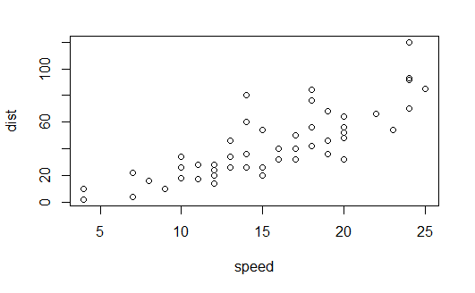

```r
library(readr)
D1 <- read_csv("D1.csv")
View(D1)

plot(cars)
```

import D1 from directory

```r
dataToCluster=D1[,-c(1)]
row.names(dataToCluster)=D1$Country
```

subsetting the data to cluster

```r
set.seed(999)
```

set random seed

```r
library(cluster)
distanceMatrix=daisy(x=dataToCluster, metric = "gower")
```

Decide distance method and using gower

```r
projectedData = cmdscale(distanceMatrix, k=2)
```

Representing the distance of 2

```r
D1$dim1 = projectedData[,1]
D1$dim2 = projectedData[,2]
D1[,c('dim1','dim2')][1:7,]
```

| dim1 | dim2 |
| --- | --- |
| -0.25482166 | 0.06603283 |
| -0.15936096 | 0.05527021 |
| -0.16258625 | -0.03601123 |
| -0.09837471 | -0.01731216 |
| -0.23903006 | -0.12850592 |
| -0.17168828 | 0.04346390 |
| -0.16528273 | 0.00388423 |

saving coordinates for each element in the data

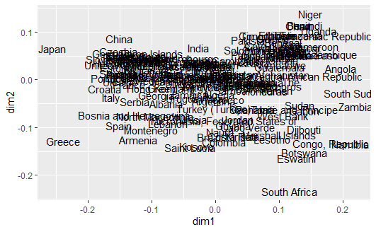

```r
library(ggplot2)
base= ggplot(data=D1,
             aes(x=dim1, y=dim2,
                 label=Country))
base + geom_text(size=4)
```

simple map of average age and population clustering

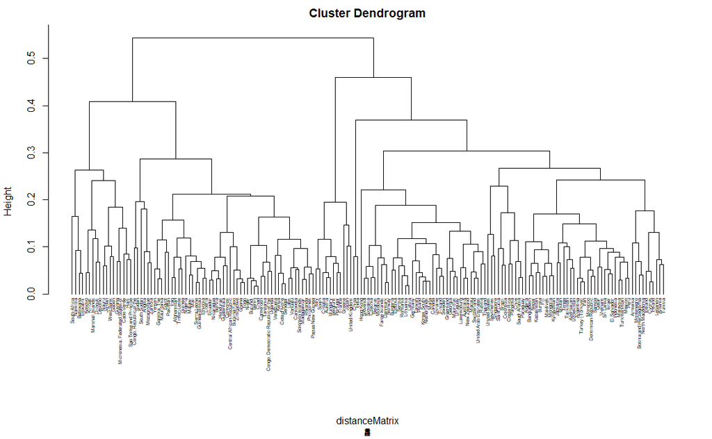

```r
hc = hclust(distanceMatrix)
subtree <- cutree(hc, k = 5)
plot(hc,hang=-1,cex=0.5,sub=subtree)
```

simple dendogram

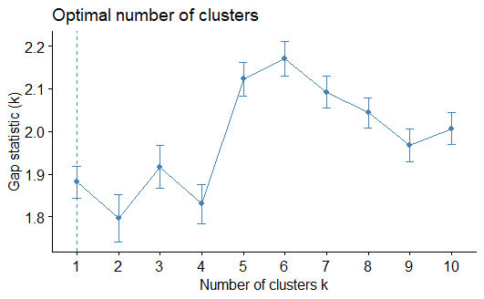

```r
library(factoextra)
fviz_nbclust(dataToCluster,
             hcut,
             diss=distanceMatrix,
             method = "gap_stat",
             k.max = 10,
             verbose = F,
             hc_func = "agnes")
```

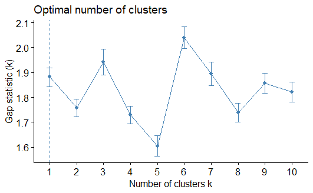

```r
fviz_nbclust(dataToCluster,
             hcut,
             diss=distanceMatrix,
             method = "gap_stat",
             k.max = 10,
             verbose = F,
             hc_func = "diana")
```

```r
NumberOfClusterDesired=6
library(factoextra)
res.agnes= hcut(distanceMatrix,
                k = NumberOfClusterDesired,
                isdiss=TRUE,
                hc_func='agnes',
                hc_method = "ward.D2")


res.diana= hcut(distanceMatrix,
                k = NumberOfClusterDesired,
                isdiss=TRUE,
                hc_func='diana',
                hc_method = "ward.D2")
```

running two different methods using the suggested number of clustering 6

```r
D1$agn=as.factor(res.agnes$cluster)
D1$dia=as.factor(res.diana$cluster)
```

save results to original data frame

```r
library(dplyr)
D1$agn=dplyr::recode_factor(D1$agn,
                  `4`='1',`1` = '2',`2`='3',`3`='4',.ordered = T)
D1$dia=dplyr::recode_factor(D1$dia,
                  `1` = '1',`3`='2',`2`='3',`4`='4',.ordered = T)
```

Ascending order

|  | cluster | size | ave.sil.width |
| --- | --- | --- | --- |
| 1 | 1 | 5 | 0.34 |
| 2 | 2 | 52 | 0.27 |
| 3 | 3 | 46 | 0.24 |
| 4 | 4 | 2 | 0.68 |
| 5 | 5 | 15 | 0.24 |
| 6 | 6 | 53 | 0.28 |

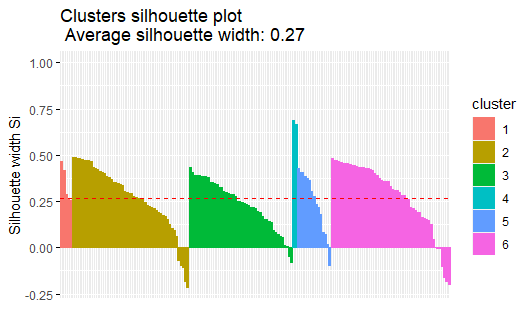

```r
fviz_silhouette(res.agnes)
```

|  | cluster | size | ave.sil.width |
| --- | --- | --- | --- |
| 1 | 1 | 14 | 0.19 |
| 2 | 2 | 55 | 0.22 |
| 3 | 3 | 13 | 0.15 |
| 4 | 4 | 2 | 0.69 |
| 5 | 5 | 19 | 0.13 |
| 6 | 6 | 70 | 0.28 |

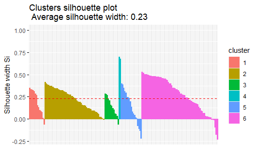

```r
library(factoextra)
fviz_silhouette(res.diana)
```

The clustering average shows a somewhat okay clustering

```r
agnEval=data.frame(res.agnes$silinfo$widths)
diaEval=data.frame(res.diana$silinfo$widths)
agnPoor=rownames(agnEval[agnEval$sil_width<0,])
diaPoor=rownames(diaEval[diaEval$sil_width<0,])
```

```r
library("qpcR")
bad_Clus=as.data.frame(qpcR:::cbind.na(sort(agnPoor),
                                       sort(diaPoor)))
names(bad_Clus)=c("agn","dia")
bad_Clus
```

| agn | dia |
| --- | --- |
| Albania | Algeria |
| Bolivia | Bhutan |
| Cambodia | Colombia |
| Chile | Costa Rica |
| Egypt | El Salvador |
| France | Guyana |
| Gabon | Iran |
| Guyana | Kosovo |
| Honduras | Lebanon |
| Lebanon | Micronesia, Federated States of |

[output cut: 4 more lines]

```r
base= ggplot(data=D1,
             aes(x=dim1, y=dim2,
                 label=Country))
agnPlot=base + labs(title = "AGNES") + geom_point(size=2,
                                              aes(color=agn),
                                              show.legend = T)
```

```r
diaPlot=base + labs(title = "DIANA") + geom_point(size=2,
                                              aes(color=dia),
                                              show.legend = T)
```

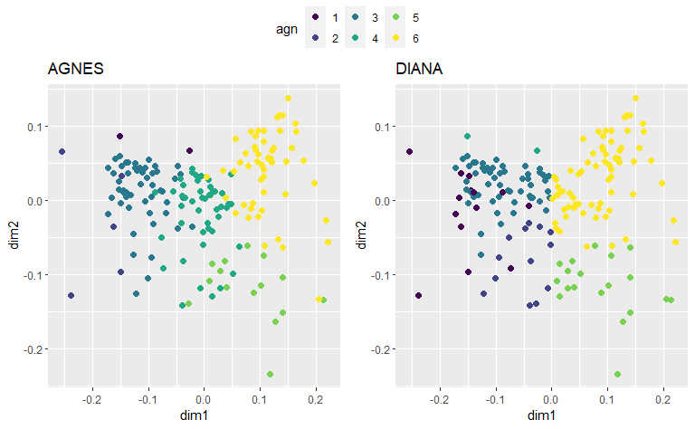

```r
library(ggpubr)
ggarrange(agnPlot, diaPlot,ncol = 2,common.legend = T)
```

```r
# If name of country in black list, use it, else get rid of it
LABELdia=ifelse(D1$Country%in%diaPoor,D1$Country,"")
LABELagn=ifelse(D1$Country%in%agnPoor,D1$Country,"")
```

```r
library(ggrepel)
diaPlot=diaPlot +
        geom_text_repel(aes(label=LABELdia),
                        max.overlaps=50,
                        min.segment.length =unit(0,'lines'))
```

```r
agnPlot= agnPlot +
         geom_text_repel(aes(label=LABELagn),
                         max.overlaps = 50,
                         min.segment.length = unit(0, 'lines'))
```

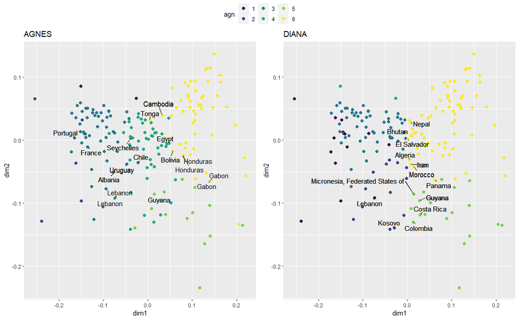

```r
ggarrange(agnPlot,
          diaPlot,
          ncol = 2,
          common.legend = T)
```

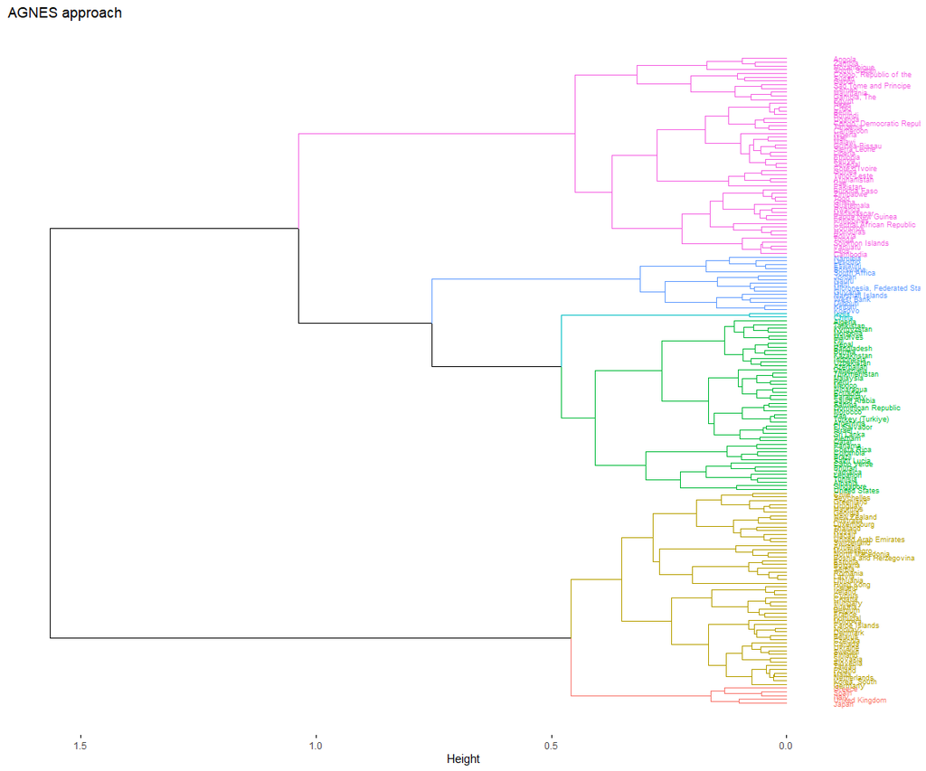

```r
fviz_dend(res.agnes,
          k=NumberOfClusterDesired,
          cex = 0.45,
          horiz = T,
          main = "AGNES approach")
```

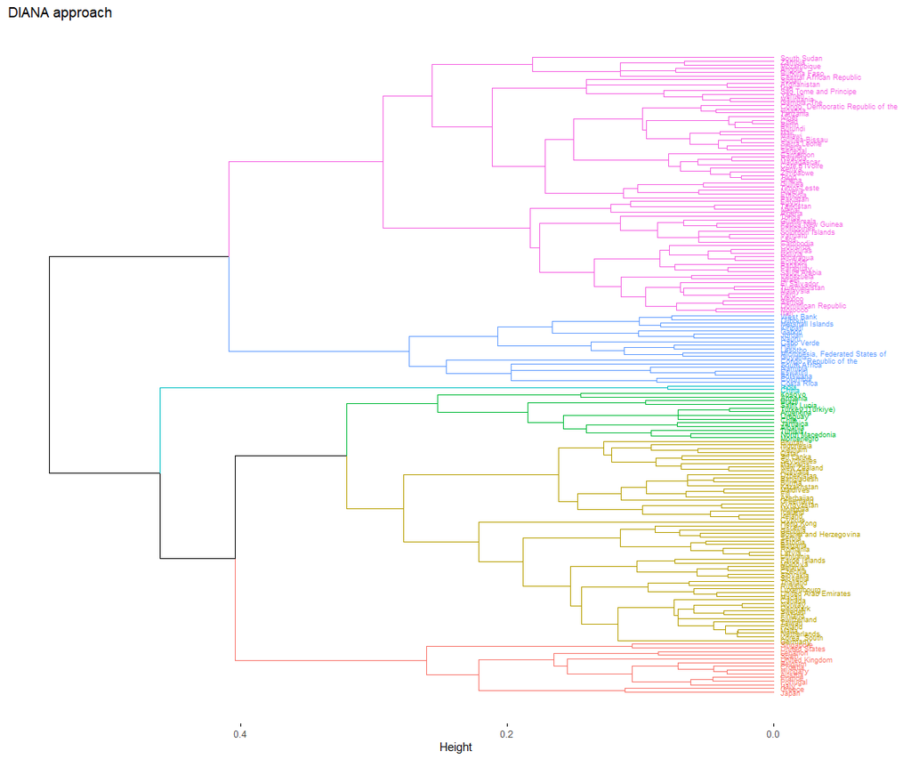

```r
fviz_dend(res.diana,
          k=NumberOfClusterDesired,
          cex = 0.45,
          horiz = T,
          main = "DIANA approach")
```

```r
table(D1$`Unemployment Rate`,D1$agn)
```

```
        1 2 3 4 5 6
  0.26  0 0 0 1 0 0
  0.61  0 0 0 0 0 1
  0.75  0 0 0 0 0 1
  1.03  0 0 0 0 0 1
  1.26  0 0 0 0 0 1
  1.42  0 0 1 0 0 0
  1.57  0 0 0 0 0 1
  1.61  0 0 0 0 0 1
  1.79  0 0 0 0 0 1
  1.88  0 0 0 0 0 1
  2.17  0 0 0 2 0 0
  2.18  0 0 0 0 0 1
  2.2   0 0 1 0 0 0
  2.41  0 0 0 0 0 1
  2.59  0 0 0 0 0 1
  2.65  0 0 0 0 0 1
  2.75  0 0 0 0 0 1
  2.8   0 1 0 0 0 0
  2.89  0 0 1 0 0 0
  2.94  0 0 0 0 0 1
  3     0 0 1 0 0 0
  3.01  0 0 1 0 0 0
  3.36  0 0 1 0 0 0
  3.37  0 0 1 0 0 0
  3.47  0 0 0 0 0 1
  3.5   0 0 1 0 0 0
  3.53  0 0 1 0 0 0
  3.54  0 0 1 0 0 0
  3.57  0 0 0 0 0 1
  3.62  0 0 0 1 0 0
  3.69  0 0 0 0 0 1
  3.72  0 0 0 0 0 1
  3.73  0 0 1 0 0 0
  3.87  0 0 0 0 0 1
  3.96  0 0 1 0 0 0
  3.97  0 0 0 0 0 1
  3.98  0 0 0 0 0 1
  4     0 0 0 0 0 1
  4.01  0 0 1 0 0 0
```

[output cut: 109 more lines]

```
  19.81 0 0 0 0 0 1
  20.9  0 0 1 0 0 0
  21.68 0 0 0 0 1 0
  22.26 0 0 0 0 0 1
  23    0 0 0 0 1 0
  23.01 0 0 0 0 0 1
  24.6  0 0 0 0 1 0
  24.72 0 0 0 0 1 0
  24.9  0 0 0 0 1 0
  25.76 0 0 0 0 1 0
  28.39 0 0 0 0 1 0
  30.5  0 0 0 0 1 0
  30.6  0 0 0 0 1 0
  33.56 0 0 0 0 1 0
  36    0 0 0 0 1 0
```

```r
table(D1$`Unemployment Rate`,D1$dia)
```

```
        1 2 3 4 5 6
  0.26  0 0 1 0 0 0
  0.61  0 0 0 0 0 1
  0.75  0 0 0 0 0 1
  1.03  0 0 0 0 0 1
  1.26  0 0 0 0 0 1
  1.42  0 0 1 0 0 0
  1.57  0 0 0 0 0 1
  1.61  0 0 0 0 0 1
  1.79  0 0 0 0 0 1
  1.88  0 0 0 0 0 1
  2.17  0 0 2 0 0 0
  2.18  0 0 0 0 0 1
  2.2   0 0 1 0 0 0
  2.41  0 0 0 0 0 1
  2.59  0 0 0 0 0 1
  2.65  0 0 0 0 0 1
  2.75  0 0 0 0 0 1
  2.8   1 0 0 0 0 0
  2.89  0 0 1 0 0 0
  2.94  0 0 0 0 0 1
  3     0 0 1 0 0 0
  3.01  0 0 1 0 0 0
  3.36  0 0 1 0 0 0
  3.37  0 0 1 0 0 0
  3.47  0 0 0 0 0 1
  3.5   0 0 1 0 0 0
  3.53  0 0 1 0 0 0
  3.54  0 0 1 0 0 0
  3.57  0 0 0 0 0 1
  3.62  1 0 0 0 0 0
  3.69  0 0 0 0 0 1
  3.72  0 0 0 0 0 1
  3.73  0 0 1 0 0 0
  3.87  0 0 0 0 0 1
  3.96  0 0 1 0 0 0
  3.97  0 0 0 0 0 1
  3.98  0 0 0 0 0 1
  4     0 0 0 0 0 1
  4.01  0 0 1 0 0 0
```

[output cut: 109 more lines]

```
  19.81 0 0 0 0 0 1
  20.9  0 1 0 0 0 0
  21.68 0 0 0 0 1 0
  22.26 0 0 0 0 1 0
  23    0 0 0 0 1 0
  23.01 0 0 0 0 1 0
  24.6  0 0 0 0 1 0
  24.72 0 0 0 0 1 0
  24.9  0 0 0 0 1 0
  25.76 0 0 0 0 1 0
  28.39 0 0 0 0 1 0
  30.5  0 1 0 0 0 0
  30.6  0 0 0 0 1 0
  33.56 0 0 0 0 1 0
  36    0 0 0 0 1 0
```

I wish to answer Question 1 Section B

what technique (diana or agned) did you use and why?

I used both method and I wanted to see what differences do they make.I did not have a better model in mind therefore I chose to run both models.

how many cases (rows) will be badly clustered?

For the Agn model, there are total of 14 bad clusters For the Diana model there are total of 13 bad clusters

[output not shown]